# R.A. Dickey Was More Underrated Than You Think

Sanjay Pothula

September 4, 2019

The R.A. Dickey trade was labeled as a terrible trade for the Blue Jays because of the prospects that they gave up and R.A. Dickey’s performance in the following years. The first part has definite merit because the Blue Jays were a 73 win team in 2012. However, the latter is not necessarily true based on the context.

As mentioned in a previous article, Fangraphs WAR relies on per-inning statistics (K/IP, BB/IP, HR/IP). For what information was likely available to Voros McCracken in 1999, it is a good statistic in that sense because he was able to create a statistic that best describes a pitcher’s value based on the information available. However, in 2019, these per-inning statistics are probably the not the best way to describe a pitcher’s value because a lot of context is lost. In the FIP formulation, batted balls are described by a pitcher’s home run rate. This means that pitchers that give up a lot of home runs will tend to give up a lot of hard batted ball contact. In this case, we are throwing away a lot of information on all batted balls. This FIP formulation especially hurts knuckleball-pitchers because they give up a lot of fly-balls, which turns into a lot of home runs, but also a lot of weak contact. This is why R.A. Dickey has been underrated based on Fangraphs WAR.

## R.A. Dickey Fangraphs WAR (2010-2015)

```
##   Season      Team Age    IP  K_9 BB_9 HR_9  FIP WAR
## 1   2010      Mets  35 174.1 5.37 2.17 0.67 3.65 2.8
## 2   2011      Mets  36 208.2 5.78 2.33 0.78 3.77 2.7
## 3   2012      Mets  37 233.2 8.86 2.08 0.92 3.27 4.7
## 4   2013 Blue Jays  38 224.2 7.09 2.84 1.40 4.58 1.8
## 5   2014 Blue Jays  39 215.2 7.22 3.09 1.09 4.32 1.8
## 6   2015 Blue Jays  40 214.1 5.29 2.56 1.05 4.48 1.8
```

## R.A. Dickey wOBA-based WAR (2010-2015)

```
##   season     Team Age    IP wOBAadj  wRAA replacementLevel WAR
## 1   2010 New York  35 174.1   0.243 25.55            14.69 4.3
## 2   2011 New York  36 208.2   0.262 14.61            17.93 3.5
## 3   2012 New York  37 233.2   0.237 38.43            19.23 6.2
## 4   2013  Toronto  38 224.2   0.268 10.35            19.63 3.2
## 5   2014  Toronto  39 215.2   0.261 16.42            19.12 3.8
## 6   2015  Toronto  40 214.1   0.260 16.74            18.49 3.8
```

Utilizing a wOBA-based model, this takes into account what all of his batted balls turned into (1B, 2B, 3B, or HR). Instead of his home runs describing him as giving up a lot of hard contact, wOBA describes him as giving up a lot of weak contact. For the 3-year period with the Blue Jays, Fangraphs describes him as a sub-2 WAR player based on a FIP-based model. Using wOBA-based WAR model, he is an above average starter with a 3+ WAR for the 3-year period. Even with his tenure with the Mets, FIP has undervalued Dickey’s contributions, especially in his Cy Young winning season in 2012 (FG WAR: 4.7, wOBA-based WAR: 6.2).

The lessons to be learned: Be Careful of what statistic you’re looking at and understand its mechanics.

## Pitching League Averages (2010-2015)

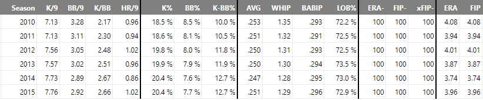

```
## # A tibble: 6 x 2
##   season wOBAadj
##   <chr>  <chr>
## 1 2010   0.282
## 2 2011   0.275
## 3 2012   0.280
## 4 2013   0.274
## 5 2014   0.279
## 6 2015   0.277
```